# Fitting a multilevel VAR(1) model

Sophie W. Berkhout

5-10-2026

### The data set

The data set we will use is from Pavani et al. (2017), made available by openESM (2025). It has the following variables:

- `id`: participant ID
- `day`: day number per individual
- `beep`: beep number per day
- `counter`: measurement occasion per individual
- `pa`: positive affect (average score between 1-5)
- `na`: negative affect (average score between 1-5)
- `appreciation`: I have taken time to savor a moment of the day (scale 1-5)

```
dat <- read.csv("0027_pavani.csv")
```

### Creating a lagged variable

We will look at the variable positive affect (`pa`). First, we will create a lagged version of this variable. Make sure that the lagged variable has a missing value for every first beep of the day. This will also make sure that the last observation of one person is not linked to the first observation of the next person.

Hint: The code from the $N=1$ data should work here as well.

```
dat$pa_lag <- NA
for (i in 2:nrow(dat)) {
  dat$pa_lag[i] <- ifelse((dat$beep[i] - dat$beep[i - 1]) == 1, dat$pa[i - 1], NA)
}
```

### Descriptives

Compute the mean and autocorrelation of each person’s positive affect and look at their distributions. Do the individuals differ a lot?

Also compute the correlations between them. How would you interpret these results?

```
cor(df_descriptives$mean, df_descriptives$autocorrelation)
```

```
[1] -0.1245228
```

There is a small negative correlation between the average positive affect and the autocorrelation, which means that people who have a higher than average positive affect tend to have a smaller autocorrelation.

### Time series plot

Select a couple of individuals and plot their time series in one figure.

```
plot(dat[dat$id == unique(dat$id)[1], "counter"], dat[dat$id == unique(dat$id)[1], "pa"], type = "l", ylim = c(1, 5))
lines(dat[dat$id == unique(dat$id)[2], "counter"], dat[dat$id == unique(dat$id)[2], "pa"], col = "blue")
```

```
lines(dat[dat$id == unique(dat$id)[3], "counter"], dat[dat$id == unique(dat$id)[3], "pa"], col = "red")
lines(dat[dat$id == unique(dat$id)[4], "counter"], dat[dat$id == unique(dat$id)[4], "pa"], col = "green")
```

```
lines(dat[dat$id == unique(dat$id)[5], "counter"], dat[dat$id == unique(dat$id)[5], "pa"], col = "orange")
```

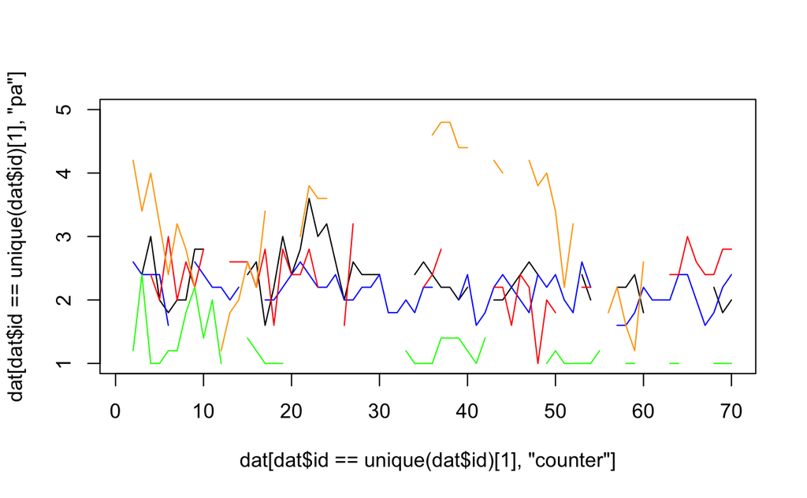

Are the time series similar in their means and variances? Some people are similar to each other, but there are also some who are quite different (e.g., the orange en green lines).

### Fit the multilevel AR(1) model

#### Linear mixed effect model with `lme4`

You can estimate a multilevel autoregressive model with a linear mixed effect model using the `lme4` package. You have to set the lagged variable as the predictor and specify a random intercept and random slope. You need another package to get p-values of the coefficients called `lmerTest`. Just loading the package should be enough to get the p-values.

You can extract the person-specific estimates with the function `coef()`.

```
summary(mod_lm)
```

```
Linear mixed model fit by REML. t-tests use Satterthwaite's method [lmerModLmerTest]
Formula: pa ~ pa_lag_c + (1 + pa_lag_c | id)
   Data: dat

REML criterion at convergence: 4991.4

Scaled residuals:
    Min      1Q  Median      3Q     Max
-5.9406 -0.5727  0.0526  0.5802  3.7266

Random effects:
 Groups   Name        Variance Std.Dev. Corr
 id       (Intercept) 0.47031  0.6858
          pa_lag_c    0.03367  0.1835   -0.08
 Residual             0.27680  0.5261
Number of obs: 2958, groups:  id, 78

Fixed effects:
            Estimate Std. Error       df t value Pr(>|t|)
(Intercept)  3.10845    0.07830 76.78550   39.70   <2e-16 ***
pa_lag_c     0.33466    0.02821 87.67786   11.86   <2e-16 ***
---
Signif. codes:  0 ‘***’ 0.001 ‘**’ 0.01 ‘*’ 0.05 ‘.’ 0.1 ‘ ’ 1

Correlation of Fixed Effects:
         (Intr)
pa_lag_c -0.060
```

How do the random effects relate to each other?

You can find the correlation under ‘Random effects:’, in the row of `pa_lag_c.` The correlation between the means (intercepts) and the autoregressions is $-0.08$. So there is barely any relation.

Plot the estimated means against the estimated autoregressions.

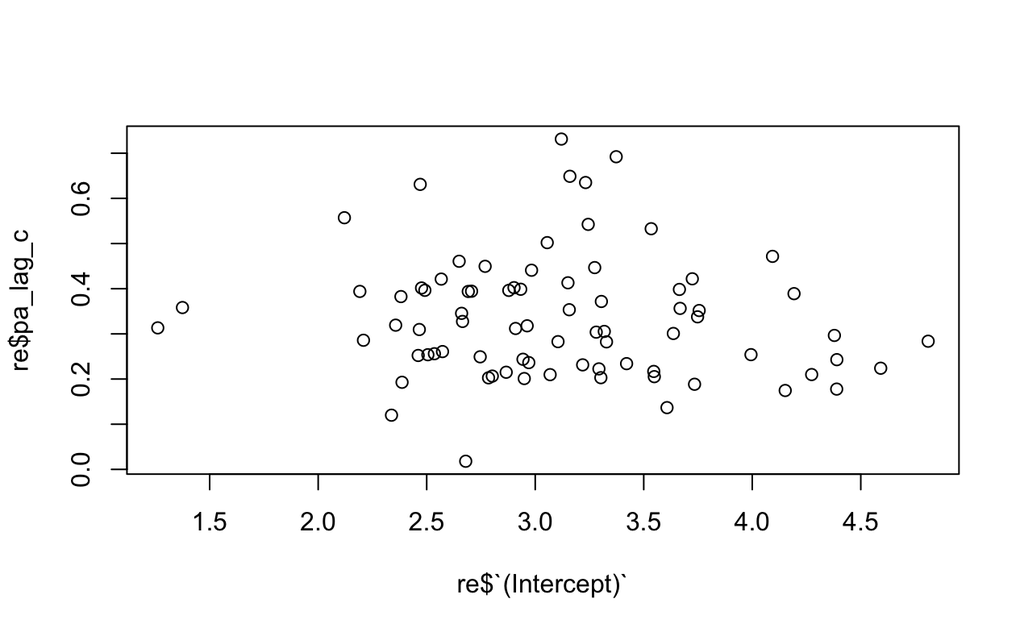

Similar to the single-level model, with this kind of univariate estimation you cannot fit a multivariate multilevel model as it does not allow for the estimation of the covariance between the innovations.

Therefore, if you are interested in fitting a multilevel vector autoregressive model, you may want to use a package that can handle multivariate estimation.

#### Multilevel (V)AR estimation with `psychonetrics`

The `psychonetrics` package can fit a multilevel autoregressive model with the `ml_gvar()` function. For this you do not need a lagged variable, the function will do this for you. You do, however, need to specify the `dayvar` and `beepvar` argument to make sure that the first beep of the day is not regressed on the last beep of the previous day.

Fit the multilevel AR(1) model using `ml_gvar()`.

```
parameters(mod_gvar)
```

```
 Parameters for group fullsample
    -  mu
   var1 op var2  est    se        p row col par
 data_c ~1      3.10 0.079 < 0.0001   1   1   1

    -  beta
   var1 op   var2  est    se        p row col par
 data_c <- data_c 0.38 0.016 < 0.0001   1   1   2

    -  delta_zeta_within (diagonal)
   var1  op   var2  est     se        p row col par
 data_c ~/~ data_c 0.54 0.0053 < 0.0001   1   1   3

    -  delta_zeta_between (diagonal)
   var1  op   var2  est    se        p row col par
 data_c ~/~ data_c 0.69 0.056 < 0.0001   1   1   4
```

Unfortunately, I have not found a way to extract the person-specific estimates using this package. I think it is because it does not estimate the person-specific effects directly.

From the [documentation](https://www.rdocumentation.org/packages/mlVAR/versions/0.7.3/topics/mlVAR) of the `mlVAR` package: “The `resimulate` method generates simulated data from a fitted `mlVAR` model using person-specific estimated parameters (fixed + random effects). For each person, a VAR time series is simulated using their estimated temporal effects (Beta), contemporaneous precision matrix (Theta), and person-specific means (mu). The output has the same dimensions and missingness pattern as the original input data, making it suitable for posterior predictive checks and model diagnostics.”

Why did I still include it in this exercise? The estimation of this function is really fast. Sometimes researchers are not interested in the person-specific estimates, and just an estimate of the variance is enough. In that case, this package is probably the most efficient option.

#### Multilevel (V)AR estimation with `mlts`

If you are interested in the person-specific estimates, there is a package called `mlts` with this functionality. It uses Bayesian estimation and makes use of the Stan software. Its estimation takes a little longer, so you have to be a bit more patient.

You need to use two functions. First, you need to specify what kind of model you want to estimate using `mlts_model()`. Then you can fit the model using `mlts_fit()`.

Note that for the specification in `mlts_fit()` the `beep` requires a different formulation than the `beepvar` argument of the `psychonetrics` package. Here, the beep number has to go up across days. For example, if there are five beeps per day, then the beep indicator of the first beep of the second day would be 6 instead of 1. Luckily, the data already came with such a variable, called `counter`.

You also need to specify how you want to deal with the night gap with the argument `n_overnight_NAs`. You have to indicate the number of NA’s that you want it to insert between the last beep of a day and the first beep of the next day. A higher number means that the effect of the ast beep of a day and the first beep of the next day is smaller. The model estimates missing data using Bayesian estimation, so you do not want to set this too high, which would make it harder to estimate the missing values.

A tutorial for a multilevel AR(1) model is provided here: https://cran.r-project.org/web/packages/mlts/vignettes/manifest_ar.html

```
mod_mlts <- mlts_fit(
  model = ar1_model,
  data = dat,
  id = "id",
  ts = "pa",
  iter = 2000,
)
```

[output not shown]

A pro of this package is that it offers multivariate estimation as well as estimation of predictor effects on the between-level. For example, you could estimate whether neuroticism (measured once) can predict the person-specific autoregressive effect estimates.

### Extra exercise

Fit a multilevel vector autoregressive model with either the `psychonetrics` or the `mlts` package. You can choose any of the variables from the data set.

```
parameters(mod_gvar)
```

```
 Parameters for group fullsample
    -  mu
 var1 op var2  est    se        p row col par
   pa ~1      3.10 0.079 < 0.0001   1   1   1
   na ~1      1.65 0.067 < 0.0001   2   1   2

    -  beta
 var1 op var2     est    se        p row col par
   pa <-   pa    0.38 0.020 < 0.0001   1   1   3
   na <-   pa  -0.017 0.020     0.40   2   1   4
   pa <-   na -0.0093 0.021     0.65   1   2   5
   na <-   na    0.40 0.019 < 0.0001   2   2   6

    -  omega_zeta_within (symmetric)
 var1 op var2   est     se        p row col par
   na --   pa -0.58 0.0093 < 0.0001   2   1   7

    -  delta_zeta_within (diagonal)
 var1  op var2  est     se        p row col par
   pa ~/~   pa 0.44 0.0043 < 0.0001   1   1   8
   na ~/~   na 0.43 0.0043 < 0.0001   2   2   9

    -  omega_zeta_between (symmetric)
 var1 op var2   est    se        p row col par
   na --   pa -0.41 0.096 < 0.0001   2   1  10

    -  delta_zeta_between (diagonal)
 var1  op var2  est    se        p row col par
   pa ~/~   pa 0.63 0.051 < 0.0001   1   1  11
   na ~/~   na 0.53 0.043 < 0.0001   2   2  12
```

### References

openESM. (2025). 0027_pavani (Version 1.0.0) [Data set]. Zenodo. https://doi.org/10.5281/zenodo.17347893

Pavani, J., Le Vigouroux, S., Kop, J., Congard, A., & Dauvier, B. (2017). A network approach to affect regulation dynamics and personality trait–induced variations: Extraversion and neuroticism moderate reciprocal influences between affect and affect regulation strategies. European Journal of Personality, 31(4), 329–346. https://doi.org/10.1002/per.2109